# Escobar & West (1995)

## Posterior predictive density p(y|D)

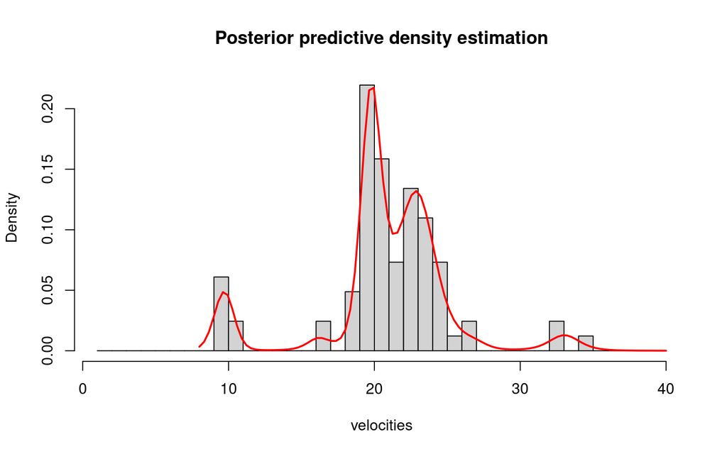

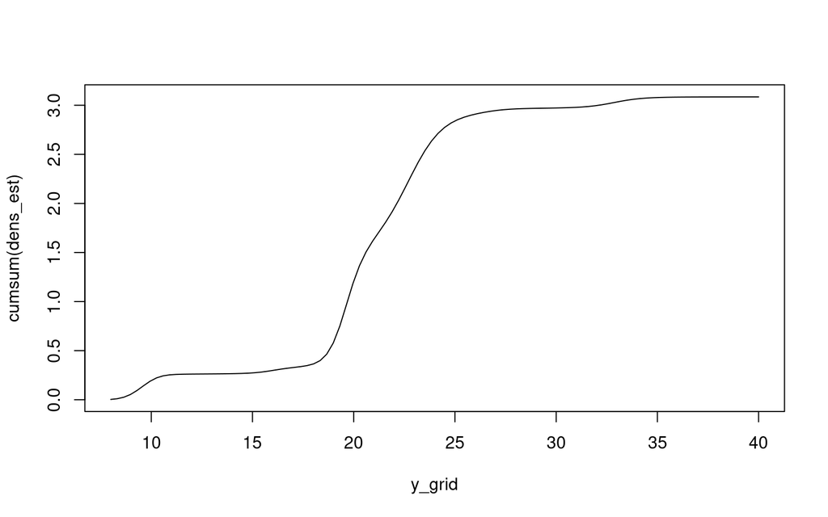

## Posterior p(tau|D)

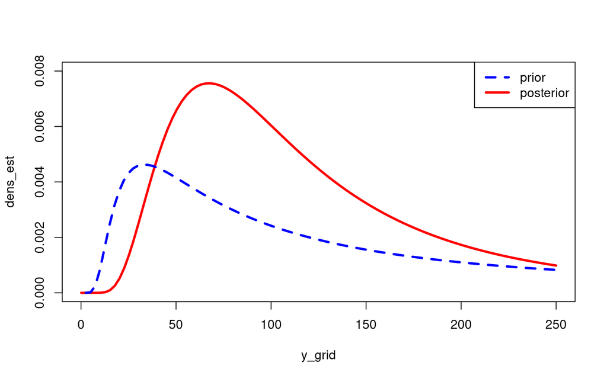

## Posterior p(alpha|D)

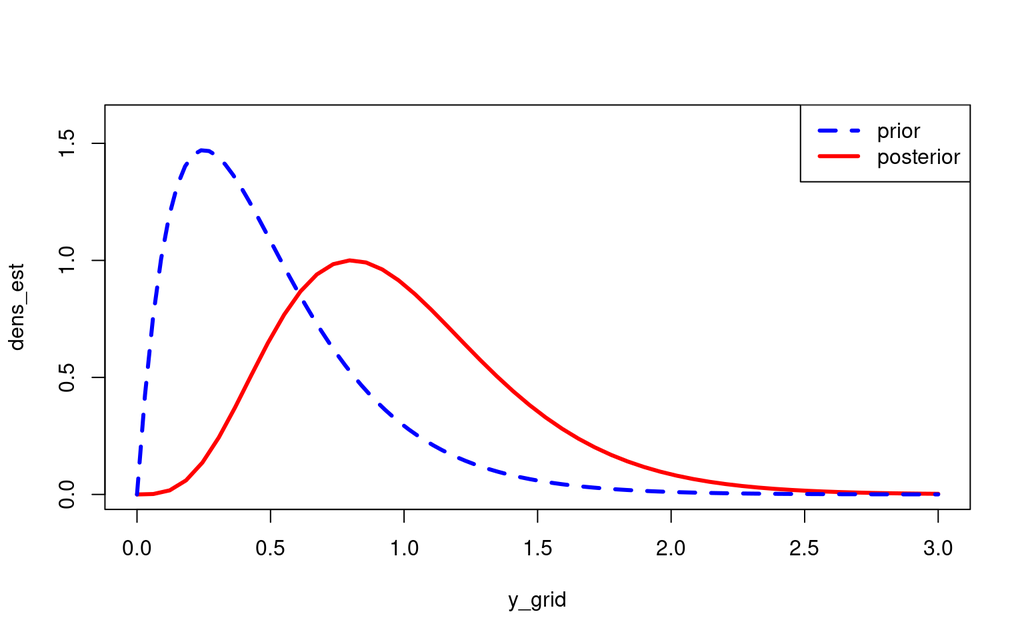

## Posterior p(k|D)

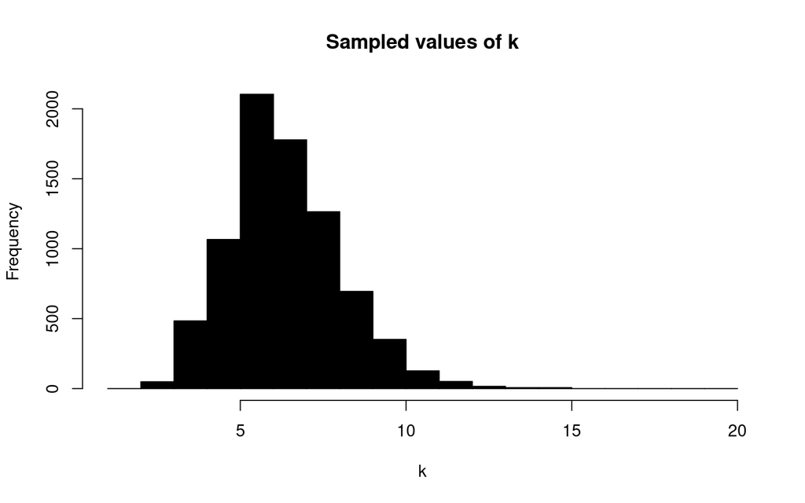

```
## k_sim
##        3        4        5        6        7        8        9       10
## 0.006125 0.060500 0.133250 0.263000 0.222250 0.158000 0.086875 0.044000
##       11       12       13       14       15
## 0.015875 0.006375 0.002000 0.000875 0.000875
```

We get almost the same results that appear in the paper.

# Notes (updated 28/09)

1. I can’t seem to retrieve $k$ correctly.
2. I implemented the first algorithm using the k different values, but now it takes much more time to get a sample.
3. Questions about the number of modes and prior predictive distribution
4. Values for $k$ are inflated, looks like there is a problem with the updating of $\pi$.
5. Mode on the initial illustration is not right
6. On the final algorithm, the posterior full conditional of $\eta$ doesn’t depend on $k$